# **Removing Duplicates**

Estimated time needed: **30** minutes

## Introduction

In this lab, you will focus on data wrangling, an important step in preparing data for analysis. Data wrangling involves cleaning and organizing data to make it suitable for analysis. One key task in this process is removing duplicate entries, which are repeated entries that can distort analysis and lead to inaccurate conclusions.

## Objectives

In this lab you will perform the following:

1. Identify duplicate rows in the dataset.
2. Use suitable techniques to remove duplicate rows and verify the removal.
3. Summarize how to handle missing values appropriately.
4. Use ConvertedCompYearly to normalize compensation data.

### Install the Required Libraries

```python
!pip install pandas
```

[output not shown]

### Step 1: Import Required Libraries

```python
import pandas as pd
```

### Step 2: Load the Dataset into a DataFrame

load the dataset using pd.read_csv()

```python
# Define the URL of the dataset
import pandas as pd

file_path = "https://cf-courses-data.s3.us.cloud-object-storage.appdomain.cloud/n01PQ9pSmiRX6520flujwQ/survey-data.csv"

try:
    # تحميل الملف مع التعامل مع الترميز
    df = pd.read_csv(file_path, encoding='utf-8')
    print("Data loaded successfully!")
    print(df.head())
except Exception as e:
    print("Error loading data:", e)
```

```
Data loaded successfully!
   ResponseId                      MainBranch                 Age  \
0           1  I am a developer by profession  Under 18 years old
1           2  I am a developer by profession     35-44 years old
2           3  I am a developer by profession     45-54 years old
3           4           I am learning to code     18-24 years old
4           5  I am a developer by profession     18-24 years old

            Employment RemoteWork   Check  \
0  Employed, full-time     Remote  Apples
1  Employed, full-time     Remote  Apples
2  Employed, full-time     Remote  Apples
3   Student, full-time        NaN  Apples
4   Student, full-time        NaN  Apples

```

[output cut: 43 more lines]

**Note: If you are working on a local Jupyter environment, you can use the URL directly in the `pandas.read_csv()` function as shown below:**

# df = pd.read_csv("https://cf-courses-data.s3.us.cloud-object-storage.appdomain.cloud/n01PQ9pSmiRX6520flujwQ/survey-data.csv")

### Step 3: Identifying Duplicate Rows

**Task 1: Identify Duplicate Rows**

1. Count the number of duplicate rows in the dataset.
2. Display the first few duplicate rows to understand their structure.

```python
# Count the number of duplicate rows
num_duplicates = df.duplicated().sum()
print("Number of duplicate rows:", num_duplicates)

# Display the first few duplicate rows
duplicate_rows = df[df.duplicated()]
print("First few duplicate rows:")
print(duplicate_rows.head())
```

```
Number of duplicate rows: 0
First few duplicate rows:
Empty DataFrame
Columns: [ResponseId, MainBranch, Age, Employment, RemoteWork, Check, CodingActivities, EdLevel, LearnCode, LearnCodeOnline, TechDoc, YearsCode, YearsCodePro, DevType, OrgSize, PurchaseInfluence, BuyNewTool, BuildvsBuy, TechEndorse, Country, Currency, CompTotal, LanguageHaveWorkedWith, LanguageWantT…
Index: []

[0 rows x 114 columns]
```

### Step 4: Removing Duplicate Rows

**Task 2: Remove Duplicates**

1. Remove duplicate rows from the dataset using the drop_duplicates() function.
2. Verify the removal by counting the number of duplicate rows after removal .

```python
## Write your code here
# Remove duplicate rows
df = df.drop_duplicates()

# Verify the removal by counting the number of duplicate rows
num_duplicates = df.duplicated().sum()
print("Number of duplicate rows after removal:", num_duplicates)
```

```
Number of duplicate rows after removal: 0
```

### Step 5: Handling Missing Values

**Task 3: Identify and Handle Missing Values**

1. Identify missing values for all columns in the dataset.
2. Choose a column with significant missing values (e.g., EdLevel) and impute with the most frequent value.

```python
## Write your code here
# Identify missing values for all columns
missing_values = df.isnull().sum()
print("Missing values per column:")
print(missing_values)

# Impute missing values in the 'EdLevel' column with the most frequent value
most_frequent = df['EdLevel'].mode()[0]
df['EdLevel'].fillna(most_frequent, inplace=True)

# Verify the imputation
print("\nMissing values in 'EdLevel' after imputation:")
print(df['EdLevel'].isnull().sum())
```

```
Missing values per column:
ResponseId                 0
MainBranch                 0
Age                        0
Employment                 0
RemoteWork             10631
                       ...
JobSatPoints_11        35992
SurveyLength            9255
SurveyEase              9199
ConvertedCompYearly    42002
JobSat                 36311
Length: 114, dtype: int64

Missing values in 'EdLevel' after imputation:
0
```

### Step 6: Normalizing Compensation Data

**Task 4: Normalize Compensation Data Using ConvertedCompYearly**

1. Use the ConvertedCompYearly column for compensation analysis as the normalized annual compensation is already provided.
2. Check for missing values in ConvertedCompYearly and handle them if necessary.

```python
## Write your code here
# Check for missing values in ConvertedCompYearly
missing_comp = df['ConvertedCompYearly'].isnull().sum()
print("Missing values in 'ConvertedCompYearly':", missing_comp)

# Handle missing values by imputing with the median
median_comp = df['ConvertedCompYearly'].median()
df['ConvertedCompYearly'].fillna(median_comp, inplace=True)

# Verify the imputation
missing_comp_after = df['ConvertedCompYearly'].isnull().sum()
print("Missing values in 'ConvertedCompYearly' after imputation:", missing_comp_after)
```

```
Missing values in 'ConvertedCompYearly': 42002
Missing values in 'ConvertedCompYearly' after imputation: 0
```

### Step 7: Summary and Next Steps

**In this lab, you focused on identifying and removing duplicate rows.**

- You handled missing values by imputing the most frequent value in a chosen column.
- You used ConvertedCompYearly for compensation normalization and handled missing values.
- For further analysis, consider exploring other columns or visualizing the cleaned dataset.

```python
pip install matplotlib seaborn
```

[output not shown]

```python
import matplotlib.pyplot as plt
import seaborn as sns
```

```
Summary statistics:
         ResponseId      CompTotal       WorkExp  JobSatPoints_1  \
count  65437.000000   3.374000e+04  29658.000000    29324.000000
mean   32719.000000  2.963841e+145     11.466957       18.581094
std    18890.179119  5.444117e+147      9.168709       25.966221
min        1.000000   0.000000e+00      0.000000        0.000000
25%    16360.000000   6.000000e+04      4.000000        0.000000
50%    32719.000000   1.100000e+05      9.000000       10.000000
75%    49078.000000   2.500000e+05     16.000000       22.000000
max    65437.000000  1.000000e+150     50.000000      100.000000

       JobSatPoints_4  JobSatPoints_5  JobSatPoints_6  JobSatPoints_7  \
count    29393.000000    29411.000000    29450.000000     29448.00000
mean         7.522140       10.060857       24.343232        22.96522
std         18.422661       21.833836       27.089360        27.01774
min          0.000000        0.000000        0.000000         0.00000
25%          0.000000        0.000000        0.000000         0.00000
50%          0.000000        0.000000       20.000000        15.00000
75%          5.000000       10.000000       30.000000        30.00000
max        100.000000      100.000000      100.000000       100.00000

       JobSatPoints_8  JobSatPoints_9  JobSatPoints_10  JobSatPoints_11  \
count    29456.000000    29456.000000     29450.000000     29445.000000
mean        20.278165       16.169432        10.955713         9.953948
std         26.108110       24.845032        22.906263        21.775652
min          0.000000        0.000000         0.000000         0.000000
25%          0.000000        0.000000         0.000000         0.000000
50%         10.000000        5.000000         0.000000         0.000000
75%         25.000000       20.000000        10.000000        10.000000
max        100.000000      100.000000       100.000000       100.000000

       ConvertedCompYearly        JobSat
count         6.543700e+04  29126.000000
mean          7.257636e+04      6.935041
std           1.122207e+05      2.088259
min           1.000000e+00      0.000000
25%           6.500000e+04      6.000000
50%           6.500000e+04      7.000000
75%           6.500000e+04      8.000000
max           1.625660e+07     10.000000
```

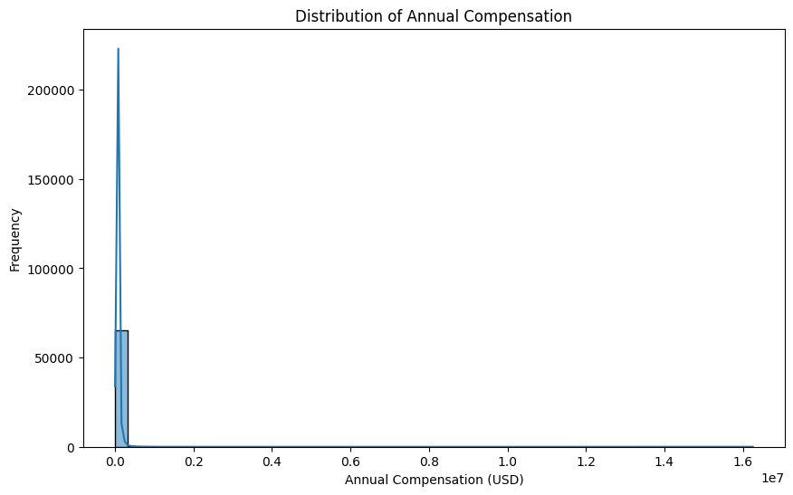

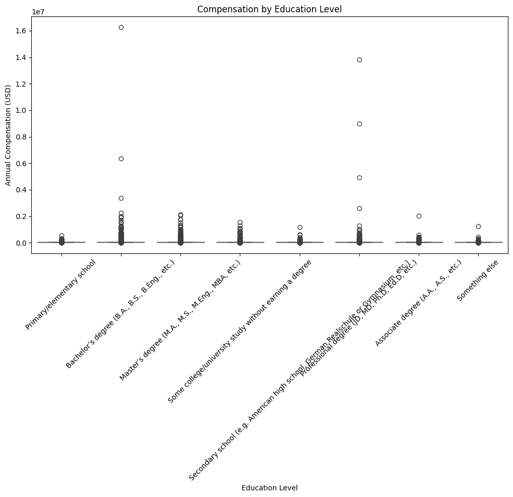

```python
## Write your code here

print("Summary statistics:")
print(df.describe())

# Visualize the distribution of annual compensation
plt.figure(figsize=(10, 6))
sns.histplot(df['ConvertedCompYearly'], bins=50, kde=True)
plt.title("Distribution of Annual Compensation")
plt.xlabel("Annual Compensation (USD)")
plt.ylabel("Frequency")
plt.show()

# Visualize the relationship between education level and compensation
plt.figure(figsize=(12, 6))
sns.boxplot(data=df, x='EdLevel', y='ConvertedCompYearly')
plt.title("Compensation by Education Level")
plt.xlabel("Education Level")
plt.ylabel("Annual Compensation (USD)")
plt.xticks(rotation=45)
plt.show()
```

Copyright © IBM Corporation. All rights reserved.